**Project: NYC Taxi Trip Duration**

ECSA Graduate Attribute Project 1

Name: Thato Xauka

Programme: WIL AI/ML Programme - Phase 1/2 (Data Foundations & EDA)

Dataset: NYC Taxi Trip Duration dataset:NYC.csv

This notebook covers Stages 1-5 of the Model Building Life Cycle:

1. Problem Definition
2. Hypothesis Generation
3. Data Extraction / Collection
4. Data Exploration and Transformation (EDA)
5. Predictive Modelling

**1.Problem Definition**

**#Used TOSCAR Method to attempt this Part - Checklist of 6 Questions**

a). **T-Trouble**

> QUESTION : What is the pain point?

> ANSWER : Riders and dispatchers receive inaccurate trip-duration estimates(ETAs), so duration is only known after the trip ends.

b). **O-Owner**

> QUESTION : Who is responsible/most impacted?

> ANSWER : Taxi companies and dispatchers, who are directly responsible for fleet allocation.

c). **S-Success Criteria**

> QUESTION : How do we measure success?

> QUESTION : What limit us?

> ANSWER : We only have historical trip records, with no live traffic or weather feed. Any future prediction would also need to run fast enough for near-real-time dispatch.

e). **A-Actors**

> QUESTION : Who interacts with the solution?

> ANSWER : Passengers (need reliable ETAs), Drivers (need fair scheduling), Dispatchers/Operations Managers (need efficient fleet allocation), Taxi companies/vendors (need revenue and trust).

f). **R-References**

> QUESTION : What existing data can we use?

> ANSWER : The historical NYC TLC Yellow Cab dataset (NYC.csv) - pickup/dropoff coordinates, timestamps, vendor info, passenger counts, and actual trip durations.

## Final Problem Statement

**Problem:** Trip duration for NYC taxi rides is unpredictable, causing dispatchers to misallocate taxis, passengers to receive unreliable ETAs, drivers to lose income from inefficient scheduling, and taxi companies to lose customer trust and revenue.

**Guiding question:** *"Which factors in a taxi trip's pickup information can help us understand and estimate trip duration before the trip begins?"*

# STAGE 2 - HYPOTHESIS GENERATION

H1 : Trips covering a **longer distance** take longer.

H2 : Trips during **rush hour** (7 to 9am, 4 to 7pm) take longer than off-peak trips.

H3 : **Weekday** trips take longer than **weekend** trips.

H4 : Trips with **more passengers** may have longer trip durations.

H5 : Trip duration may differ between the **two vendors**.

H6 : Trips taken at **different times of the day** may have different trip durations.

# STAGE 3 - Data Extraction / Collection

```python
# 1. Importing Libraries:
import pandas as pd
import numpy as np
import matplotlib.pyplot as plt
import seaborn as sns
from scipy import stats
```

```python
 # - loading my dataset (NYC.csv):
data = pd.read_csv('NYC.csv')
```

```python
#2. File structure and content & Data Types:
#first 5 instances using "head()" function: check, not to analyze
data.head()
```

|  | id | vendor_id | pickup_datetime | dropoff_datetime | passenger_count | pickup_longitude | pickup_latitude | dropoff_longitude | dropoff_latitude | store_and_fwd_flag | trip_duration |
| --- | --- | --- | --- | --- | --- | --- | --- | --- | --- | --- | --- |
| 0 | id2875421 | 2 | 2016-03-14 17:24:55 | 2016-03-14 17:32:30 | 1 | -73.982155 | 40.767937 | -73.964630 | 40.765602 | N | 455 |
| 1 | id2377394 | 1 | 2016-06-12 00:43:35 | 2016-06-12 00:54:38 | 1 | -73.980415 | 40.738564 | -73.999481 | 40.731152 | N | 663 |
| 2 | id3858529 | 2 | 2016-01-19 11:35:24 | 2016-01-19 12:10:48 | 1 | -73.979027 | 40.763939 | -74.005333 | 40.710087 | N | 2124 |
| 3 | id3504673 | 2 | 2016-04-06 19:32:31 | 2016-04-06 19:39:40 | 1 | -74.010040 | 40.719971 | -74.012268 | 40.706718 | N | 429 |
| 4 | id2181028 | 2 | 2016-03-26 13:30:55 | 2016-03-26 13:38:10 | 1 | -73.973053 | 40.793209 | -73.972923 | 40.782520 | N | 435 |

```python
data.tail()
```

|  | id | vendor_id | pickup_datetime | dropoff_datetime | passenger_count | pickup_longitude | pickup_latitude | dropoff_longitude | dropoff_latitude | store_and_fwd_flag | trip_duration |
| --- | --- | --- | --- | --- | --- | --- | --- | --- | --- | --- | --- |
| 1458639 | id2376096 | 2 | 2016-04-08 13:31:04 | 2016-04-08 13:44:02 | 4 | -73.982201 | 40.745522 | -73.994911 | 40.740170 | N | 778 |
| 1458640 | id1049543 | 1 | 2016-01-10 07:35:15 | 2016-01-10 07:46:10 | 1 | -74.000946 | 40.747379 | -73.970184 | 40.796547 | N | 655 |
| 1458641 | id2304944 | 2 | 2016-04-22 06:57:41 | 2016-04-22 07:10:25 | 1 | -73.959129 | 40.768799 | -74.004433 | 40.707371 | N | 764 |
| 1458642 | id2714485 | 1 | 2016-01-05 15:56:26 | 2016-01-05 16:02:39 | 1 | -73.982079 | 40.749062 | -73.974632 | 40.757107 | N | 373 |
| 1458643 | id1209952 | 1 | 2016-04-05 14:44:25 | 2016-04-05 14:47:43 | 1 | -73.979538 | 40.781750 | -73.972809 | 40.790585 | N | 198 |

```python
data.shape
```

```
(1458644, 11)
```

```python
data.columns
```

```
Index(['id', 'vendor_id', 'pickup_datetime', 'dropoff_datetime',
       'passenger_count', 'pickup_longitude', 'pickup_latitude',
       'dropoff_longitude', 'dropoff_latitude', 'store_and_fwd_flag',
       'trip_duration'],
      dtype='str')
```

```python
data.dtypes
```

```
id                        str
vendor_id               int64
pickup_datetime           str
dropoff_datetime          str
passenger_count         int64
pickup_longitude      float64
pickup_latitude       float64
dropoff_longitude     float64
dropoff_latitude      float64
store_and_fwd_flag        str
trip_duration           int64
dtype: object
```

**END OF STAGE 3!!!!!!!!!!!!**

# Stage 4 - Data Exploration and Transformation (EDA)

```python
#3. Detect missing values:
data.isnull().sum()
```

```
id                    0
vendor_id             0
pickup_datetime       0
dropoff_datetime      0
passenger_count       0
pickup_longitude      0
pickup_latitude       0
dropoff_longitude     0
dropoff_latitude      0
store_and_fwd_flag    0
trip_duration         0
dtype: int64
```

```python
#4. Reformatting features & Checking consistency(1. converting strings to datetime features, 2. Converting yes/no flag to 1 and 0:
#Part 1 : Converting strings to datetime features
data['pickup_datetime'] = pd.to_datetime(data['pickup_datetime'])
data['dropoff_datetime'] = pd.to_datetime(data['dropoff_datetime'])
```

```python
data.dtypes
```

```
id                               str
vendor_id                      int64
pickup_datetime       datetime64[us]
dropoff_datetime      datetime64[us]
passenger_count                int64
pickup_longitude             float64
pickup_latitude              float64
dropoff_longitude            float64
dropoff_latitude             float64
store_and_fwd_flag               str
trip_duration                  int64
dtype: object
```

```python
#Part 2: Converting the yes/no flag to 1 and 0:
data['store_and_fwd_flag'] = data['store_and_fwd_flag'].astype('category')
data['store_and_fwd_flag'] = data['store_and_fwd_flag'].cat.codes
```

```python
data.dtypes
```

```
id                               str
vendor_id                      int64
pickup_datetime       datetime64[us]
dropoff_datetime      datetime64[us]
passenger_count                int64
pickup_longitude             float64
pickup_latitude              float64
dropoff_longitude            float64
dropoff_latitude             float64
store_and_fwd_flag              int8
trip_duration                  int64
dtype: object
```

```python
data['store_and_fwd_flag'].value_counts()
```

```
store_and_fwd_flag
0    1450599
1       8045
Name: count, dtype: int64
```

```python
#4. Target Exploration(count,mean, std, min, 25%, 50%, 75%,& max ): STATS
data['trip_duration'].describe()
```

```
count    1.458644e+06
mean     9.594923e+02
std      5.237432e+03
min      1.000000e+00
25%      3.970000e+02
50%      6.620000e+02
75%      1.075000e+03
max      3.526282e+06
Name: trip_duration, dtype: float64
```

> There are 1,458,644 trips with no missing values.

> The average trip is about 960 seconds (16 minutes), but the standard deviation (5,237 seconds) is over 5 times bigger than the mean itself - that's a major red flag telling you the data has extreme outliers dragging the average around.

> The median (662 seconds, = 11 min) is a much more realistic "typical trip" than the mean.

> The maximum value (3,526,282 seconds = 40.8 days) confirms this - no real taxi trip lasts 40 days, so this is clearly a data error or extreme outlier that needs to be handled...

> Mean > Median = right-skewed (long tail of high values) : Mean = 959.5 > Median (50%) = 662 - general rule

**#5. Log trip_duration and plot your result as pdf.**

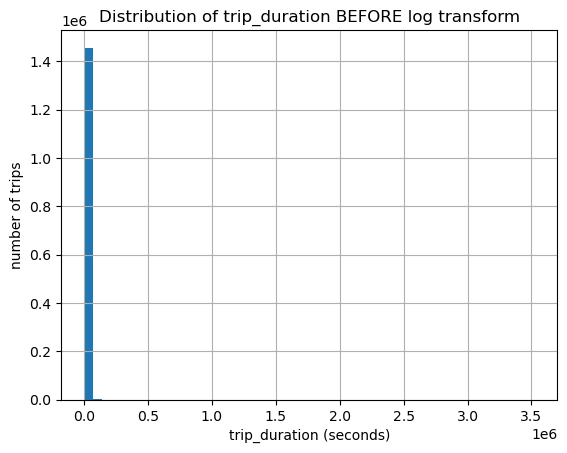

```python
#Step 1 : Before log transform:
data['trip_duration'].hist(bins=50)
plt.xlabel('trip_duration (seconds)')
plt.ylabel('number of trips')
plt.title('Distribution of trip_duration BEFORE log transform')
plt.show()
```

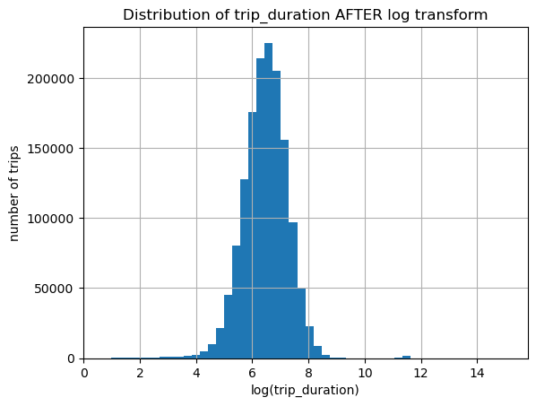

```python
# Step 2: After log transform
data['log_trip_duration'] = np.log1p(data['trip_duration'])

data['log_trip_duration'].hist(bins=50)
plt.xlabel('log(trip_duration)')
plt.ylabel('number of trips')
plt.title('Distribution of trip_duration AFTER log transform')
plt.savefig('trip_duration_after_log.pdf')
plt.show()
```

# Observation Report: Distribution of Trip Duration Before and After Log Transformation

The trip duration distribution before the log transformation is highly right-skewed. Most trips are concentrated at the lower end of the distribution, while a small number of trips have extremely large durations. These extreme values stretch the x-axis to very high values, making it difficult to clearly see the distribution of the majority of trips.

After applying the log transformation using log1p(), the distribution becomes much more balanced and approximately bell-shaped. The transformation reduces the influence of the extremely large trip-duration values and spreads out the observations that were previously concentrated near zero.

This shows that the log transformation is useful for reducing the strong right-skewness and making the distribution easier to analyse and visualise. It does not remove the original observations; instead, it compresses the scale of very large values.

**6. Carry out the following Univariate Visualization again individual frequency (passenger count, vendor ID, store and forward flag) and explain your observation**

```python
data['passenger_count'].value_counts().sort_index()
```

```
passenger_count
0         60
1    1033540
2     210318
3      59896
4      28404
5      78088
6      48333
7          3
8          1
9          1
Name: count, dtype: int64
```

```python
#the percentage share each passenger count makes up of the whole dataset:
#1,033,540 (trips with 1 passenger) ÷ 1,458,644 (total trips) × 100 = 70.86%
data['passenger_count'].value_counts(normalize=True) * 100
```

```
passenger_count
1    70.856220
2    14.418734
5     5.353465
3     4.106280
6     3.313557
4     1.947288
0     0.004113
7     0.000206
9     0.000069
8     0.000069
Name: proportion, dtype: float64
```

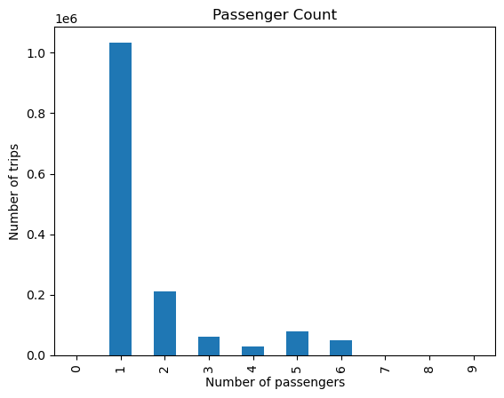

```python
data['passenger_count'].value_counts().sort_index().plot(kind='bar')
plt.xlabel('Number of passengers')
plt.ylabel('Number of trips')
plt.title('Passenger Count')
plt.show()
```

**Observation Report:**

Most taxi trips carry just 1 passenger with 1,033,540 trips, well over 70% of the entire dataset. This is by far the dominant pattern, confirming NYC taxis are mostly used for solo rides.

Outliers

0 passengers (60 trips) : a confirmed outlier and data error. A taxi cannot legally dispatch with zero passengers, so these rows are almost certainly mistakes, not real trips.

5 and 6 passengers (78,088 and 48,333 trips) : a genuine grey area, not confirmed either way. Standard NYC yellow cabs (sedans) are typically licensed for only 4 passengers, so these could come from larger accessible vehicles, or could be errors - this dataset alone doesn't provide enough information to say which.

7, 8, 9 passengers (1–3 trips each) : too rare to represent any real pattern. Almost certainly errors, or at minimum, extreme edge cases not worth drawing conclusions from.

```python
# Frequency table for vendor_id - Variable: Vendor ID
data['vendor_id'].value_counts() #[vendor+trips]
```

```
vendor_id
2    780302
1    678342
Name: count, dtype: int64
```

```python
#calculates what percentage share each vendor makes up of the total dataset:
data['vendor_id'].value_counts(normalize=True) * 100
```

```
vendor_id
2    53.495027
1    46.504973
Name: proportion, dtype: float64
```

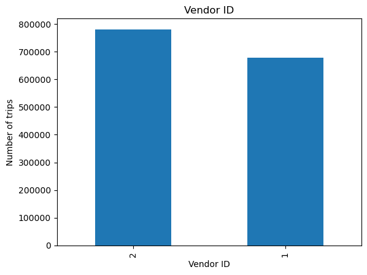

```python
data['vendor_id'].value_counts().plot(kind='bar')
plt.xlabel('Vendor ID')
plt.ylabel('Number of trips')
plt.title('Vendor ID')
plt.show()
```

**Observation Report:**

> Vendor 2 recorded 780,302 trips, while Vendor 1 recorded 678,342 trips. Vendor 2 was used more often across the dataset than Vendor 1.

Vendor 1 recorded 678,342 trips (46.5% of the dataset), while Vendor 2 recorded 780,302 trips (53.5%).

The split between the two vendors is fairly balanced, with Vendor 2 handling a slightly larger share of total trips - roughly 100,000 more than Vendor 1, but not an extreme imbalance either way.

```python
# [1/yes = stored] -- [flag values+trips]
data['store_and_fwd_flag'].value_counts()
```

```
store_and_fwd_flag
0    1450599
1       8045
Name: count, dtype: int64
```

```python
data['store_and_fwd_flag'].value_counts(normalize=True) * 100
```

```
store_and_fwd_flag
0    99.44846
1     0.55154
Name: proportion, dtype: float64
```

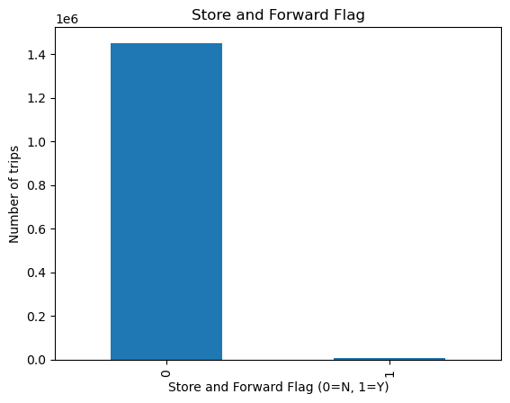

```python
data['store_and_fwd_flag'].value_counts().plot(kind='bar')
plt.xlabel('Store and Forward Flag (0=N, 1=Y)')
plt.ylabel('Number of trips')
plt.title('Store and Forward Flag')
plt.show()
```

**Observation Report**

The store_and_fwd_flag shows that most trip records were sent directly to the server, with 1,450,599 trips (99.45%) having a value of 0.

Only 8,045 trips (0.55%) have a value of 1, meaning the trip data was stored in the vehicle first and forwarded to the server later, indicating that the data was not transmitted immediately.

Most trips, 1,450,599 (99.45%) - have store_and_fwd_flag = 0, while only 8,045 trips (0.55%) have store_and_fwd_flag = 1.

This shows that the vast majority of trips in the dataset have a store-and-forward flag of 0, with only a very small proportion having the flag set to 1.

The variable is therefore highly imbalanced between the two categories.

**7. Find your pickup time in week day and hour and plot them again total number of pickup.**

```python
#extracting the weekday name (e.g. "Monday") from the full timestamp and save it as a new column:
data['pickup_weekday'] = data['pickup_datetime'].dt.day_name()

#extracting just the hour (0-23) from the full timestamp and save it as a new column:
data['pickup_hour'] = data['pickup_datetime'].dt.hour
```

```python
#defining the correct calendar order for days of the week (Monday first, Sunday last):
weekday_order = ['Monday','Tuesday','Wednesday','Thursday','Friday','Saturday','Sunday']

#counting how many pickups happened on each weekday, then re-ordering the result to follow weekday_order instead of pandas' default alphabetical order:
data['pickup_weekday'].value_counts().reindex(weekday_order)
```

```
pickup_weekday
Monday       187418
Tuesday      202749
Wednesday    210136
Thursday     218574
Friday       223533
Saturday     220868
Sunday       195366
Name: count, dtype: int64
```

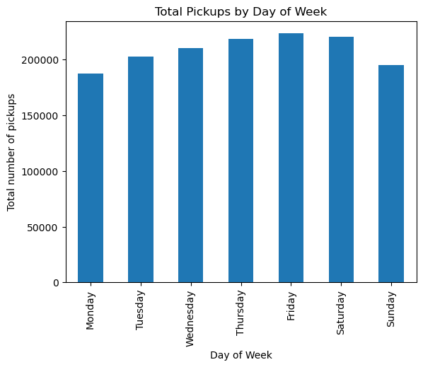

```python
data['pickup_weekday'].value_counts().reindex(weekday_order).plot(kind='bar')
plt.xlabel('Day of Week')
plt.ylabel('Total number of pickups')
plt.title('Total Pickups by Day of Week')
plt.show()
```

**OBSERVATIONG:**

Monday has the fewest pickups (187,418), rising through Tuesday, Wednesday, and Thursday, and reaching the highest level on Friday (223,533). Saturday remains almost as high (220,868), before decreasing on Sunday (195,366).

This shows a clear weekly pattern in pickup demand: pickups generally increase from Monday through Friday, remain high on Saturday, and then decrease on Sunday.

However, this analysis only measures the number of pickups, not trip duration. Therefore, it does not confirm or reject H3 at this stage. The relationship between weekday/weekend timing and trip duration will be tested later in the bivariate analysis.

```python
#counting pickups per hour (0-23), then sort by hour number instead of by frequency:
data['pickup_hour'].value_counts().sort_index()
```

```
pickup_hour
0     53248
1     38571
2     27972
3     20895
4     15792
5     15002
6     33248
7     55600
8     67053
9     67663
10    65437
11    68476
12    71873
13    71473
14    74292
15    71811
16    64313
17    76483
18    90600
19    90308
20    84072
21    84185
22    80492
23    69785
Name: count, dtype: int64
```

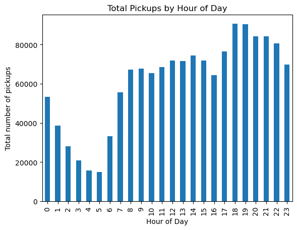

```python
data['pickup_hour'].value_counts().sort_index().plot(kind='bar')
plt.xlabel('Hour of Day')
plt.ylabel('Total number of pickups')
plt.title('Total Pickups by Hour of Day')
plt.show()
```

**Observation Report : Pickup Time by Weekday and Hour**

Pickups are lowest during the early morning hours, particularly around 2am–5am. Pickup volume then increases throughout the day, reaching the highest levels during the evening hours, especially around 18:00–21:00.

This shows that taxi demand varies considerably depending on the time of day, with substantially more trips occurring during the daytime and evening than during the early morning.

However, this analysis only measures the number of pickups by hour, not trip duration. Therefore, it does not confirm or reject H2 at this stage. The relationship between rush-hour periods and trip duration will be tested later in the bivariate analysis.

**8. Latitude & Longitude-Do distribution plots on pickup and drop-off latitude and longitude.**

checking whether the location data (pickup/dropoff coordinates) is clean, realistic, and consistent : before trusting it for any later analysis or mapping.

```python
#my statstical summary...:
data[['pickup_latitude',
      'pickup_longitude',
      'dropoff_latitude',
      'dropoff_longitude']].describe()
```

|  | pickup_latitude | pickup_longitude | dropoff_latitude | dropoff_longitude |
| --- | --- | --- | --- | --- |
| count | 1.458644e+06 | 1.458644e+06 | 1.458644e+06 | 1.458644e+06 |
| mean | 4.075092e+01 | -7.397349e+01 | 4.075180e+01 | -7.397342e+01 |
| std | 3.288119e-02 | 7.090186e-02 | 3.589056e-02 | 7.064327e-02 |
| min | 3.435970e+01 | -1.219333e+02 | 3.218114e+01 | -1.219333e+02 |
| 25% | 4.073735e+01 | -7.399187e+01 | 4.073588e+01 | -7.399133e+01 |
| 50% | 4.075410e+01 | -7.398174e+01 | 4.075452e+01 | -7.397975e+01 |
| 75% | 4.076836e+01 | -7.396733e+01 | 4.076981e+01 | -7.396301e+01 |
| max | 5.188108e+01 | -6.133553e+01 | 4.392103e+01 | -6.133553e+01 |

```python
#checking if a value falls inside that range (returns True or False for every row)
nyc_box = data[(data['pickup_longitude'].between(-74.05,-73.75)) &
               (data['pickup_latitude'].between(40.6,40.9)) &
               (data['dropoff_longitude'].between(-74.05,-73.75)) &
               (data['dropoff_latitude'].between(40.6,40.9))]
```

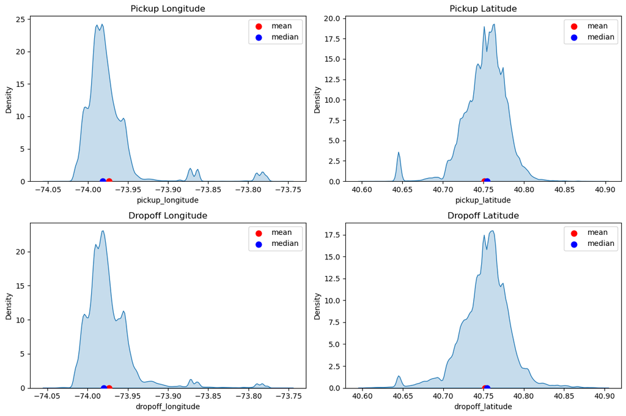

```python
fig, axes = plt.subplots(2, 2, figsize=(12,8))

cols = ['pickup_longitude', 'pickup_latitude', 'dropoff_longitude', 'dropoff_latitude']
titles = ['Pickup Longitude', 'Pickup Latitude', 'Dropoff Longitude', 'Dropoff Latitude']
positions = [(0,0), (0,1), (1,0), (1,1)]

for col, title, pos in zip(cols, titles, positions):
    ax = axes[pos]
    sns.kdeplot(nyc_box[col], ax=ax, fill=True)

    mean_val = nyc_box[col].mean()
    median_val = nyc_box[col].median()

    ax.scatter([mean_val], [0], color='red', marker='o', s=60, label='mean', zorder=5)
    ax.scatter([median_val], [0], color='blue', marker='o', s=60, label='median', zorder=5)

    ax.set_title(title)
    ax.legend()

plt.tight_layout()
plt.show()
```

**Observation Report**

Observation Report

The four coordinate variables : pickup latitude, pickup longitude, dropoff latitude, and dropoff longitude, show that most taxi trips are concentrated within a relatively small geographic area around New York City.

The .describe() results show 1,458,644 values for each coordinate column, indicating that the coordinate fields contain no missing values. The mean and median values are also very close to each other, while the 25%, 50%, and 75% values are tightly grouped around approximately 40.7 latitude and -74.0 longitude. This indicates that the majority of trips follow a consistent geographic pattern.

However, the minimum and maximum values are much farther away from the main range of the data. For example, pickup latitude ranges from approximately 34.36 to 51.88, while pickup longitude ranges from approximately -121.93 to -61.33. These extreme values fall outside the normal range identified using the IQR rule and are therefore treated as geographical outliers.

The NYC geographic bounding box was then applied to focus the KDE plots on trips whose pickup and drop-off coordinates fall within the expected NYC area.

The KDE plots show that the filtered coordinate values are strongly concentrated around the NYC region. The mean and median markers are close together across all four distributions, showing that the main body of the coordinate data is relatively consistent.

Overall, the coordinate data is largely clean and geographically consistent, but a small number of extreme coordinate values were identified as outliers. These outliers should be handled carefully before using the coordinates for later geographical analysis or modelling.

**9. Bivariate Relations with Target-After your exploration of related data, plot trip duration against day of the week, and trip duration against hour of the week.**

```python
weekday_order = ['Monday','Tuesday','Wednesday','Thursday','Friday','Saturday','Sunday']

data.groupby('pickup_weekday')['trip_duration'].mean().reindex(weekday_order)
```

```
pickup_weekday
Monday        897.947839
Tuesday       983.463124
Wednesday     975.450494
Thursday     1006.528654
Friday        990.224200
Saturday      948.051175
Sunday        901.639395
Name: trip_duration, dtype: float64
```

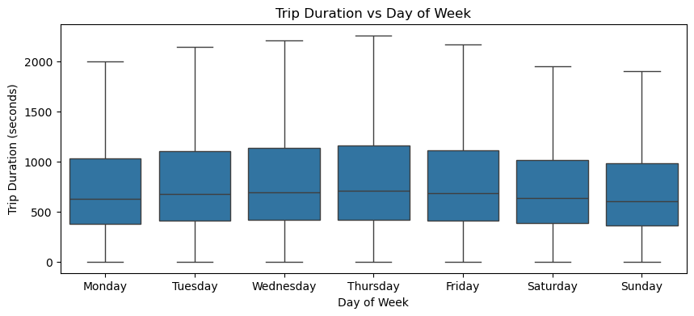

```python
plt.figure(figsize=(10,4))
sns.boxplot(x='pickup_weekday', y='trip_duration', data=data, order=weekday_order, showfliers=False)
plt.xlabel('Day of Week')
plt.ylabel('Trip Duration (seconds)')
plt.title('Trip Duration vs Day of Week')
plt.show()
```

```python
data.groupby('pickup_hour')['trip_duration'].mean() #Average Trip Duration by Hour
```

```
pickup_hour
0      936.657302
1      903.087112
2      890.076934
3      890.070878
4      921.976444
5      822.298960
6      797.434943
7      831.758345
8      924.559199
9      933.528915
10     933.367605
11     966.430282
12     993.533079
13    1032.246359
14    1075.789264
15    1118.832533
16    1080.146285
17    1030.581619
18     981.583234
19     894.356679
20     879.461545
21     890.521221
22    1023.455921
23     925.091409
Name: trip_duration, dtype: float64
```

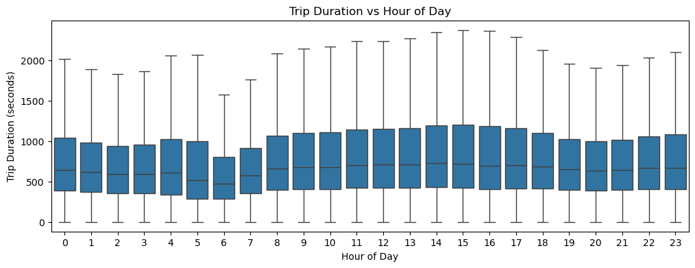

```python
plt.figure(figsize=(12,4))
sns.boxplot(x='pickup_hour', y='trip_duration', data=data, showfliers=False)
plt.xlabel('Hour of Day')
plt.ylabel('Trip Duration (seconds)')
plt.title('Trip Duration vs Hour of Day')
plt.show()
```

# Observation Report : Bivariate Relations with Target

Hour of day: Average trip duration is lowest in the early morning (6am, 797s) and highest in the afternoon (3pm, 1,119s), with a second smaller peak around 10pm (1,024s).

Duration rises steadily through the morning, dips slightly in the evening, then rises again briefly at night. H2 is partially supported: trip duration does vary meaningfully by hour, consistent with traffic and demand patterns, but the true peak isn't the classic 7-9am or 4-7pm rush hour windows specified in the hypothesis, it's mid-afternoon (2-4pm, 1,119s), so the hypothesis captures the general pattern but not the specific timing.

**10. Plot vendor_id vs Trip Duration**

```python
data.groupby('vendor_id')['trip_duration'].mean() #stats be4...
```

```
vendor_id
1     845.438244
2    1058.643164
Name: trip_duration, dtype: float64
```

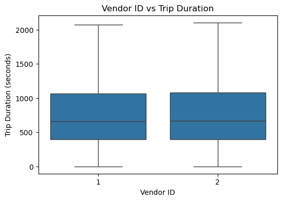

```python
plt.figure(figsize=(6,4))
sns.boxplot(x='vendor_id', y='trip_duration', data=data, showfliers=False)
plt.xlabel('Vendor ID')
plt.ylabel('Trip Duration (seconds)')
plt.title('Vendor ID vs Trip Duration')
plt.show()
```

**Observation Report : Vendor ID vs Trip Duration**

The average trip duration differs between the two vendors. Vendor 1 has an average trip duration of 845.4 seconds, while Vendor 2 has a higher average of 1,058.6 seconds, giving a difference of approximately 213 seconds.

However, the median trip durations are much closer. Vendor 1 has a median of approximately 658 seconds, while Vendor 2 has a median of approximately 666 seconds, a difference of only 8 seconds.

The boxplot also shows that the overall distributions are broadly similar, although Vendor 2 has a slightly higher central tendency. The large difference between the means compared with the small difference between the medians suggests that extreme trip durations may be influencing the mean, particularly for Vendor 2.

Therefore, H5 is supported only partially: there is a clear difference in the mean trip duration between the vendors, but the median results show that their typical trip durations are very similar. This suggests that vendor may have some relationship with trip duration, but the difference should be interpreted cautiously because the mean appears to be affected by extreme values.

**11. Find Median Trip Duration Vendor Wise and Plot This**

```python
data.groupby('vendor_id')['trip_duration'].median()
```

```
vendor_id
1    658.0
2    666.0
Name: trip_duration, dtype: float64
```

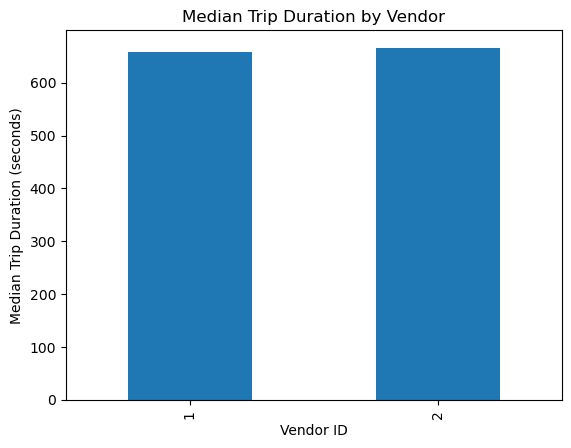

```python
data.groupby('vendor_id')['trip_duration'].median().plot(kind='bar')
plt.title('Median Trip Duration by Vendor')
plt.xlabel('Vendor ID')
plt.ylabel('Median Trip Duration (seconds)')
plt.show()
```

# Observation Report :

The median trip duration is very similar between the two vendors. Vendor 1 has a median trip duration of 658 seconds (approximately 11 minutes), while Vendor 2 has a median of 666 seconds (approximately 11.1 minutes).

The difference is only 8 seconds, showing that the typical trip duration for customers using either vendor is almost the same.

This also explains the difference observed earlier in the mean trip durations, where Vendor 2 had a much higher average. Since the median is much less affected by extreme values, the close medians suggest that unusually long trips may have increased Vendor 2's mean.

Overall, the median results indicate that both vendors have a very similar typical trip duration, despite the difference observed in their mean trip durations.

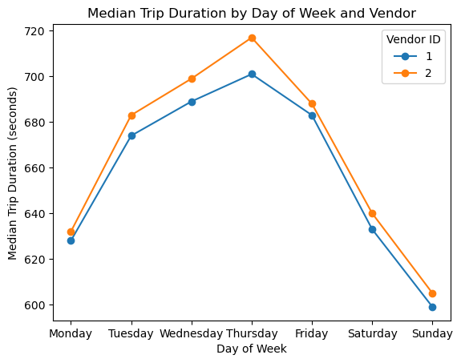

```python
#XII.Find Median Trip Duration Vendor Wise and plot this:
#plot this....:
weekday_order = ['Monday','Tuesday','Wednesday','Thursday','Friday','Saturday','Sunday']

data.groupby(['pickup_weekday', 'vendor_id'])['trip_duration'].median().unstack().reindex(weekday_order).plot(kind='line', marker='o')
plt.title('Median Trip Duration by Day of Week and Vendor')
plt.xlabel('Day of Week')
plt.ylabel('Median Trip Duration (seconds)')
plt.legend(title='Vendor ID')
plt.show()
```

**Observation Report**

The plain vendor-wise median shows Vendor 1 at 658 seconds and Vendor 2 at 666 seconds, which is only an 8-second difference. Breaking this down further by day of week shows that both vendors follow a very similar weekly pattern. Median trip duration peaks on Thursday at approximately 701 seconds for Vendor 1 and 717 seconds for Vendor 2, then drops to its lowest on Sunday, at approximately 599 seconds and 605 seconds, respectively.

The two lines remain very close and almost parallel across the week, with Vendor 2 consistently slightly higher than Vendor 1. This indicates that the small difference between the vendors is generally consistent across different days rather than being caused by one particular day.

Conclusion: Based on the median, both vendors have very similar typical trip durations, with Vendor 2 only slightly higher throughout the week.

**12. Determine and Plot Trip Duration vs Passenger Count**

```python
data.groupby('passenger_count')['trip_duration'].mean()
```

```
passenger_count
0    1718.433333
1     930.399753
2    1005.458335
3    1028.236276
4    1053.529749
5    1070.232174
6    1061.355223
7      19.666667
8     104.000000
9     560.000000
Name: trip_duration, dtype: float64
```

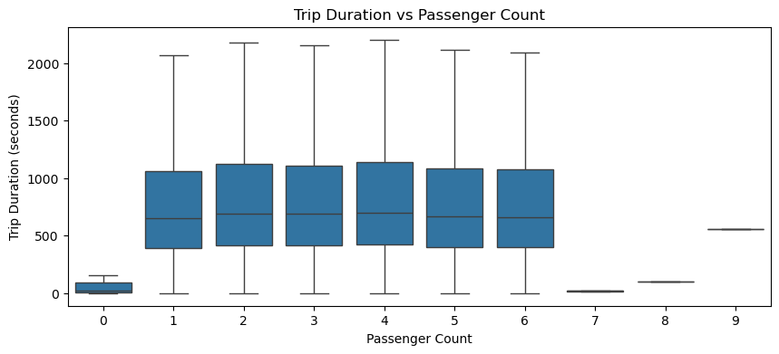

```python
plt.figure(figsize=(10,4))
sns.boxplot(x='passenger_count', y='trip_duration', data=data, showfliers=False)
plt.xlabel('Passenger Count')
plt.ylabel('Trip Duration (seconds)')
plt.title('Trip Duration vs Passenger Count')
plt.show()
```

**Report : Trip Duration vs Passenger Count**

Average duration rises gradually from 1 passenger (930s) through 6 passengers (1,061s): a mild, steady increase, not a dramatic one. Median duration tells a similar, more stable story across 1-6 passengers (654 to 698 seconds), confirming this is a real but weak effect, matching what H4 predicted.

The extreme cases confirm the same warning from before:

0 passengers shows a mean of 1,718s but median of only 20.5s, a huge mismatch, and further proof this group (60 trips) is broken data, not a real pattern.

7, 8, 9 passengers show wildly different means (19.7s, 104s, 560s), but remember, these are based on just 1-3 trips each. A single trip's duration isn't a meaningful "average" of anything, these numbers swing entirely because of tiny sample size, not a real relationship between passenger count and duration.

Boxplot note: the boxes for 7, 8, 9 will likely look flat or oddly thin, expected, since a boxplot needs several values to show a real spread, and there simply isn't enough data there.

Bottom line: passenger count shows a weak association with trip duration for the common 1–6 passenger groups, although the relationship is not perfectly consistent (duration dips slightly from 5 to 6 passengers rather than increasing all the way through), and the dramatic-looking swings at 7-9 are a small-sample illusion, not a genuine pattern.

**13. Visualise most frequently occuring Pickup points on the latitude- longitude Map and research packages that can provide you with this type of visualization.**

```python
import folium
from folium.plugins import HeatMap
```

```python
nyc_box = data[(data['pickup_longitude'].between(-74.05,-73.75)) &
               (data['pickup_latitude'].between(40.6,40.9))]
```

```python
sample = nyc_box.sample(5000, random_state=42)
```

```python
m = folium.Map(location=[40.76, -73.98], zoom_start=11, tiles="OpenStreetMap")
HeatMap(data=sample[['pickup_latitude', 'pickup_longitude']].values.tolist()).add_to(m)
m
```

Make this Notebook Trusted to load map: File -> Trust Notebook

[interactive chart not shown]

**Observation Report**

Areas outside Manhattan (outer boroughs, airports) show noticeably lighter, more scattered activity, confirming that NYC yellow taxi demand is overwhelmingly an inner-city phenomenon rather than evenly spread across the city.

```python
data['day_of_week'] = data['pickup_datetime'].dt.dayofweek
data['hour_of_day'] = data['pickup_hour']
```

```python
data[['pickup_datetime', 'pickup_hour', 'day_of_week', 'hour_of_day']].head()
```

|  | pickup_datetime | pickup_hour | day_of_week | hour_of_day |
| --- | --- | --- | --- | --- |
| 0 | 2016-03-14 17:24:55 | 17 | 0 | 17 |
| 1 | 2016-06-12 00:43:35 | 0 | 6 | 0 |
| 2 | 2016-01-19 11:35:24 | 11 | 1 | 11 |
| 3 | 2016-04-06 19:32:31 | 19 | 2 | 19 |
| 4 | 2016-03-26 13:30:55 | 13 | 5 | 13 |

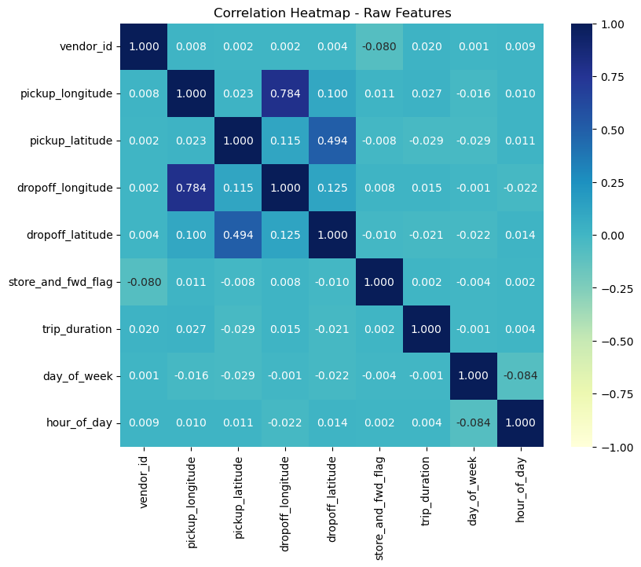

```python
heatmap_cols = ['vendor_id', 'pickup_longitude', 'pickup_latitude', 'dropoff_longitude',
                'dropoff_latitude', 'store_and_fwd_flag', 'trip_duration', 'day_of_week',
                'hour_of_day']

corr_matrix = data[heatmap_cols].astype('float64').corr()

plt.figure(figsize=(9,7))
sns.heatmap(corr_matrix, cmap='YlGnBu', vmin=-1, vmax=1, square=True, annot=True, fmt='.3f')
plt.title('Correlation Heatmap - Raw Features')
plt.show()
```

# Report : Correlation Heatmap (Raw Features)

# Stage 5 - Predictive Modeling

# Checking missing values

```python
data.isnull().sum()
```

```
id                    0
vendor_id             0
pickup_datetime       0
dropoff_datetime      0
passenger_count       0
pickup_longitude      0
pickup_latitude       0
dropoff_longitude     0
dropoff_latitude      0
store_and_fwd_flag    0
trip_duration         0
log_trip_duration     0
pickup_weekday        0
pickup_hour           0
day_of_week           0
hour_of_day           0
dtype: int64
```

```python
# Checking for duplicate rows:
print("Number of duplicate rows:", data.duplicated().sum())
```

```
Number of duplicate rows: 0
```

# Categorical Variables

```python
data.dtypes
```

```
id                               str
vendor_id                      int64
pickup_datetime       datetime64[us]
dropoff_datetime      datetime64[us]
passenger_count                int64
pickup_longitude             float64
pickup_latitude              float64
dropoff_longitude            float64
dropoff_latitude             float64
store_and_fwd_flag              int8
trip_duration                  int64
log_trip_duration            float64
pickup_weekday                   str
pickup_hour                    int32
day_of_week                    int32
hour_of_day                    int32
dtype: object
```

# Dropping Unnecessary Columns

```python
model_data = data.drop(columns=[
    'id', 'pickup_datetime', 'dropoff_datetime',
    'log_trip_duration', 'pickup_weekday', 'pickup_hour'
])

model_data.dtypes
```

```
vendor_id               int64
passenger_count         int64
pickup_longitude      float64
pickup_latitude       float64
dropoff_longitude     float64
dropoff_latitude      float64
store_and_fwd_flag       int8
trip_duration           int64
day_of_week             int32
hour_of_day             int32
dtype: object
```

# DEALING WITH OUTLIERS:

```python
Q1 = model_data['trip_duration'].quantile(0.25)  # 25th percentile
Q3 = model_data['trip_duration'].quantile(0.75)  # 75th percentile
IQR = Q3 - Q1

whisker_1 = Q1 - (1.5 * IQR)
whisker_2 = Q3 + (1.5 * IQR)

whisker_1, whisker_2
```

```
(np.float64(-620.0), np.float64(2092.0))
```

```python
#checking how many outliers I have and what percentage:based on the IQR rule:
outliers_iqr = model_data.loc[model_data['trip_duration'] > whisker_2]
print(len(outliers_iqr))
print(len(outliers_iqr) / len(model_data) * 100)
```

```
74220
5.088287477958981
```

# Report:

Using the IQR method on trip_duration, 74,220 trips (5.09% of the data) would be flagged as outliers because they are longer than 35 minutes. I decided not to remove these trips using this method, because a taxi trip taking longer than 35 minutes is still a normal, realistic trip in a big city like New York, not necessarily an error. Removing over 74,000 valid trips just because they are long would take away real information the model needs to learn from. Instead of using the IQR cutoff,

I used a simple domain based rule in the follwing code...: to keep only trips that last between 1 minute and 4 hours, since anything shorter than 1 minute is not a realistic taxi fare, and anything longer than 4 hours is very unlikely for a normal trip.

```python
print("Before cleaning:", model_data.shape)

# Keep trips between 1 minute and 4 hours
model_data = model_data[(model_data['trip_duration'] >= 60) & (model_data['trip_duration'] <= 4*3600)]

print("After cleaning:", model_data.shape)
```

```
Before cleaning: (1458644, 10)
After cleaning: (1447972, 10)
```

# Report:

I applied the domain based cutoff, keeping only trips between 1 minute and 4 hours. This removed 10,672 trips, of the original dataset (1,458,644 rows), leaving 1,447,972 rows. This is a much smaller and safer amount of data lost compared to the strict IQR method, which would have removed over 74,000 trips.

```python
#passenger_count outliers:
Q1 = model_data['passenger_count'].quantile(0.25)
Q3 = model_data['passenger_count'].quantile(0.75)
IQR = Q3 - Q1

whisker_1 = Q1 - (1.5 * IQR)
whisker_2 = Q3 + (1.5 * IQR)

whisker_1, whisker_2
```

```
(np.float64(-0.5), np.float64(3.5))
```

# Report:

Using the IQR method on passenger_count, the upper whisker came out to 3.5. This means any trip with 4 or more passengers would be flagged as an outlier by this method. The lower whisker was -0.5, which is not meaningful since a trip cannot have a negative number of passengers.

```python
#to see how many trips that would actually affect:
outliers_pass = model_data.loc[model_data['passenger_count'] > 3.5]
print(len(outliers_pass))
print(len(outliers_pass) / len(model_data) * 100)
```

```
153849
10.625136397665148
```

# Report:

Using the IQR method on passenger_count, 153,849 trips (10.63% of the data) would be flagged as outliers because they have 4 or more passengers. I decided not to remove these trips, because carrying 4, 5, or 6 passengers is a normal, realistic situation for a taxi (for example a group or a family sharing a ride), not an error in the data. Removing over 150,000 valid trips would take away a large amount of real information the model needs. Instead of the IQR cutoff, I used a domain based rule: keep only trips with between 1 and 6 passengers, since 0 passengers is not a valid trip, and vehicles are not realistically expected to carry more than 6 people.

```python
#removing trips with 0 passengers or more than 6 passengers:
print("Before cleaning:", model_data.shape)

model_data = model_data[(model_data['passenger_count'] >= 1) & (model_data['passenger_count'] <= 6)]

print("After cleaning:", model_data.shape)
```

```
Before cleaning: (1447972, 10)
After cleaning: (1447953, 10)
```

# Report:

```python
# Calculating the normal range for pickup_longitude using the IQR method,
# to find cutoff points for what counts as an unusually far-out location
Q1 = model_data['pickup_longitude'].quantile(0.25)
Q3 = model_data['pickup_longitude'].quantile(0.75)
IQR = Q3 - Q1
whisker_1 = Q1 - (1.5 * IQR)
whisker_2 = Q3 + (1.5 * IQR)
whisker_1, whisker_2
```

```
(np.float64(-74.02855300903323), np.float64(-73.93074417114255))
```

```python
# Counting how many trips have a pickup_longitude outside the IQR cutoffs
outliers_pickup_lon = model_data.loc[
    (model_data['pickup_longitude'] < whisker_1) | (model_data['pickup_longitude'] > whisker_2)
]
print(len(outliers_pickup_lon))
print(len(outliers_pickup_lon) / len(model_data) * 100)
```

```
82350
5.687339298996584
```

# Report:

Using the IQR method on pickup_longitude, the normal range cutoffs came out to approximately -74.03 (lower) and -73.93 (upper). Any pickup with a longitude outside this narrow range would be flagged as a statistical outlier.

```python
# Re-Checking the summary stats (min, max, etc.....) for all four coordinate columns
model_data[['pickup_longitude', 'pickup_latitude', 'dropoff_longitude', 'dropoff_latitude']].describe()
```

|  | pickup_longitude | pickup_latitude | dropoff_longitude | dropoff_latitude |
| --- | --- | --- | --- | --- |
| count | 1.447953e+06 | 1.447953e+06 | 1.447953e+06 | 1.447953e+06 |
| mean | -7.397361e+01 | 4.075097e+01 | -7.397354e+01 | 4.075185e+01 |
| std | 7.077532e-02 | 3.267813e-02 | 7.053544e-02 | 3.573201e-02 |
| min | -1.219333e+02 | 3.435970e+01 | -1.219333e+02 | 3.218114e+01 |
| 25% | -7.399187e+01 | 4.073740e+01 | -7.399133e+01 | 4.073594e+01 |
| 50% | -7.398177e+01 | 4.075413e+01 | -7.397977e+01 | 4.075456e+01 |
| 75% | -7.396742e+01 | 4.076836e+01 | -7.396310e+01 | 4.076982e+01 |
| max | -6.133553e+01 | 5.188108e+01 | -6.133553e+01 | 4.392103e+01 |

# Report:

Looking at the actual minimum and maximum values, the coordinates go far beyond anything possible for a New York City taxi trip. For example, pickup_longitude ranges from about -121.93 to -61.34, and pickup_latitude ranges from about 34.36 to 51.88. New York City itself sits at roughly -74.05 to -73.75 longitude and 40.6 to 40.9 latitude, so these extreme values are clearly GPS recording errors, not real trips. This confirms that some outliers in the coordinate columns are genuine data errors, not just unusual but valid locations.

However, the IQR method flagged 82,350 trips (5.69%), which likely includes many real trips near the edges of the city, not just the broken GPS points. Instead of removing that much data, let's directly filter to a realistic NYC boundary box.

```python
# Checking how many trips fall outside a realistic NYC boundary box
outside_nyc = model_data.loc[
    ~model_data['pickup_longitude'].between(-74.05, -73.75) |
    ~model_data['pickup_latitude'].between(40.60, 40.90) |
    ~model_data['dropoff_longitude'].between(-74.05, -73.75) |
    ~model_data['dropoff_latitude'].between(40.60, 40.90)
]
print(len(outside_nyc))
print(len(outside_nyc) / len(model_data) * 100)
```

```
6915
0.47757074987931236
```

# Report:

Using a realistic NYC boundary box (longitude between -74.05 and -73.75, latitude between 40.60 and 40.90), only 6,915 trips (0.48%) fall outside this range. This is a much smaller and safer amount of data to remove compared to the strict IQR method, which would have flagged 82,350 trips. This confirms that most of the coordinate outliers were genuine GPS errors far outside the city, not normal edge-of-city trips, so filtering to this boundary is a better approach than the IQR method.

```python
 #removing trips outside NYC’s valid map limits...:
print("Before cleaning:", model_data.shape)

model_data = model_data[
    model_data['pickup_longitude'].between(-74.05, -73.75) &
    model_data['pickup_latitude'].between(40.60, 40.90) &
    model_data['dropoff_longitude'].between(-74.05, -73.75) &
    model_data['dropoff_latitude'].between(40.60, 40.90)
]

print("After cleaning:", model_data.shape)
```

```
Before cleaning: (1447953, 10)
After cleaning: (1441038, 10)
```

# Report:

A realistic NYC coordinate boundary was applied to remove extreme geographic errors. This removed 6,915 observations (0.48%). Although some trips outside the boundary could represent legitimate journeys, the boundary was used as a practical preprocessing rule to exclude highly abnormal geographic observations from the modelling dataset.

# Feature Engineering:

```python
def haversine(lat1, lon1, lat2, lon2):
    R = 6371  # Earth's radius in km(sets Earth’s radius in kilometers)

    #Converting Degrees to Radians
    lat1, lon1, lat2, lon2 = map(np.radians, [lat1, lon1, lat2, lon2])

    dlat = lat2 - lat1
    dlon = lon2 - lon1

    a = np.sin(dlat/2)**2 + np.cos(lat1) * np.cos(lat2) * np.sin(dlon/2)**2
    c = 2 * np.arcsin(np.sqrt(a))

    return R * c

#Creates a new column trip_distance_km with the calculated distance for each trip
model_data['trip_distance_km'] = haversine(
    model_data['pickup_latitude'],
    model_data['pickup_longitude'],
    model_data['dropoff_latitude'],
    model_data['dropoff_longitude']
)

model_data['trip_distance_km'].describe()
```

```
count    1.441038e+06
mean     3.387194e+00
std      3.777935e+00
min      0.000000e+00
25%      1.241645e+00
50%      2.097103e+00
75%      3.851502e+00
max      3.308128e+01
Name: trip_distance_km, dtype: float64
```

# Report:

The trip_distance_km feature was created using the Haversine formula, which calculates the approximate distance between the pickup and dropoff coordinates.

The average trip distance is about 3.39 km, while the median is about 2.10 km. This shows that most taxi trips in the dataset are relatively short.

The maximum straight-line distance is approximately 33.08 km. This is plausible for trips whose pickup and drop-off locations are within the selected geographic boundary.

The distance feature provides the model with a more meaningful measurement of the trip than using the four latitude and longitude values separately.

```python
# Checking how many trips have a distance of exactly 0 km (pickup and dropoff at the same point)
zero_distance = model_data.loc[model_data['trip_distance_km'] == 0]
print(len(zero_distance))
print(len(zero_distance) / len(model_data) * 100)
```

```
4027
0.2794513399369066
```

# Report:

There are 4,027 trips, representing about 0.28% of the dataset, where the calculated distance between the pickup and dropoff coordinates is 0 km.

These observations were not automatically removed because a zero straight-line distance does not necessarily mean that the trip is invalid. The pickup and dropoff coordinates may have been recorded at the same or rounded location, even though the taxi may have travelled a short distance.

Since these observations represent only a very small percentage of the dataset, they were retained rather than removed without stronger evidence that they are incorrect.

# Train/test Setup Stage:

-Separating predictors (X) from the target (y):

```python
# Separating features (X) and target (y) now that outlier cleaning and feature engineering are complete:
X = model_data.drop(columns=['trip_duration'])
y = model_data['trip_duration']

print(X.shape, y.shape)
print(X.columns.tolist())
```

```
(1441038, 10) (1441038,)
['vendor_id', 'passenger_count', 'pickup_longitude', 'pickup_latitude', 'dropoff_longitude', 'dropoff_latitude', 'store_and_fwd_flag', 'day_of_week', 'hour_of_day', 'trip_distance_km']
```

# Report:

I separated the cleaned data into X (features) and y (target), now that outlier cleaning and feature engineering are complete. X contains 1,441,038 rows and 10 columns, these are all the variables the model will use to make predictions: vendor_id, passenger_count, pickup and dropoff coordinates, store_and_fwd_flag, day_of_week, hour_of_day, and the trip_distance_km feature engineered earlier. y contains the same number of rows (1,441,038) but just one value per row: trip_duration, the value the model is trying to predict. This confirms the data is correctly split into inputs and target, ready for the train/test split.

```python
# Export cleaned data for Tableau dashboard
model_data.to_csv('NYC_cleaned_for_tableau.csv', index=False)
print("Cleaned data exported for Tableau.")
```

```
Cleaned data exported for Tableau.
```

```python
print(model_data['trip_duration'].describe())
```

```
count    1.441038e+06
mean     8.356947e+02
std      6.512991e+02
min      6.000000e+01
25%      4.000000e+02
50%      6.630000e+02
75%      1.069000e+03
max      1.424300e+04
Name: trip_duration, dtype: float64
```

# Train/Test Split

```python
# Split the data into training and testing sets BEFORE scaling, to avoid data leakage
from sklearn.model_selection import train_test_split

X_train, X_test, y_train, y_test = train_test_split(
    X, y, test_size=0.2, random_state=42
)

print("Train:", X_train.shape)
print("Test:", X_test.shape)
```

```
Train: (1152830, 10)
Test: (288208, 10)
```

# Report:

The data was split into a training set and a testing set, with 1,152,830 trips (80%) used for training and 288,208 trips (20%) used for testing. The split was done before any scaling was applied, to avoid data leakage, if scaling was done on the full dataset first, information from the test set could influence the training process, which would give an unfair advantage and unrealistic performance results.

# Feature Scaling

```python
# Scaling features using StandardScaler. The scaler is fit ONLY on training data
# to avoid test data leakage, then used to transform both train and test sets.
from sklearn.preprocessing import StandardScaler

scaler = StandardScaler()
X_train_scaled = scaler.fit_transform(X_train)
X_test_scaled = scaler.transform(X_test)

print("Scaling done")
```

```
Scaling done
```

# Report:

I scaled the features so that they are all on the same level. In the dataset, some values are small (like passenger_count which goes from 1 to 6), while others are much bigger (like trip_distance_km which can be over 30, and latitude/longitude which are large decimal numbers). If I do not scale, the big numbers can overpower the small ones, and the model will not learn fairly.

I used StandardScaler from scikit‑learn. This tool changes each feature so that its average is close to 0 and its spread is close to 1. I fit the scaler only on the training data to avoid leaking information from the test set, and then applied it to both training and test sets to keep things consistent.

After running the code, the message “Scaling done” confirmed that the process worked. This step makes sure models that are sensitive to feature size, such as **regression**, and **KNN**, can perform properly with each feature contributing fairly to predicting trip_duration.

# KNN Regression (baseline model)

{model training and evaluation step using KNN regression}

```python
# Training a baseline KNN Regressor with K=5
from sklearn.neighbors import KNeighborsRegressor
from sklearn.metrics import mean_absolute_error, mean_squared_error, r2_score
import numpy as np

knn = KNeighborsRegressor(n_neighbors=5)
knn.fit(X_train_scaled, y_train)

y_pred = knn.predict(X_test_scaled)

mae = mean_absolute_error(y_test, y_pred)
rmse = np.sqrt(mean_squared_error(y_test, y_pred))
r2 = r2_score(y_test, y_pred)

print(f"MAE: {mae:.2f} seconds")
print(f"RMSE: {rmse:.2f} seconds")
print(f"R2: {r2:.4f}")
```

```
MAE: 208.45 seconds
RMSE: 335.93 seconds
R2: 0.7337
```

# Report:

A baseline KNN Regressor was trained using K=5 (the default starting point, before testing other K values). The model achieved an MAE of 208.45 seconds, meaning predictions were off by about 3.5 minutes on average. The RMSE was 335.93 seconds, which is higher than the MAE, since RMSE penalizes larger errors more heavily, suggesting there are some trips where the prediction was significantly off. The R2 score of 0.7337 means the model explains about 73% of the variation in trip duration, which is a reasonably strong starting point before any tuning.

# Choosing the Best K (using a sample, to keep it fast)

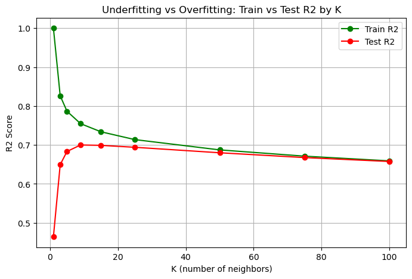

[output not shown]

```python
# Testing different K values on a sample of training data (to save time),
# to see which K gives the best performance without overfitting or underfitting
from sklearn.neighbors import KNeighborsRegressor
from sklearn.metrics import r2_score
import matplotlib.pyplot as plt

train_data = X_train.copy()
train_data['trip_duration'] = y_train.values

sample = train_data.sample(n=50000, random_state=42)
X_sample = sample.drop(columns=['trip_duration'])
y_sample = sample['trip_duration']

Xs_train, Xs_test, ys_train, ys_test = train_test_split(
    X_sample, y_sample, test_size=0.2, random_state=42
)

sample_scaler = StandardScaler()
Xs_train_scaled = sample_scaler.fit_transform(Xs_train)
Xs_test_scaled = sample_scaler.transform(Xs_test)

k_values = [1, 3, 5, 9, 15, 25, 50, 75, 100]
train_scores = []
test_scores = []

for k in k_values:
    model = KNeighborsRegressor(n_neighbors=k, n_jobs=-1)
    model.fit(Xs_train_scaled, ys_train)
    train_scores.append(r2_score(ys_train, model.predict(Xs_train_scaled)))
    test_scores.append(r2_score(ys_test, model.predict(Xs_test_scaled)))

plt.figure(figsize=(8,5))
plt.plot(k_values, train_scores, marker='o', color='green', label='Train R2')
plt.plot(k_values, test_scores, marker='o', color='red', label='Test R2')
plt.xlabel('K (number of neighbors)')
plt.ylabel('R2 Score')
plt.title('Underfitting vs Overfitting: Train vs Test R2 by K')
plt.legend()
plt.grid(True)
plt.show()

print(list(zip(k_values, train_scores, test_scores)))
```

# Report:

Different K values were tested to find a suitable balance between overfitting and underfitting by comparing the training and testing R² scores.

At K = 1, the training R² is 1.00 while the test R² is only 0.464, showing clear overfitting. As K increases, the test R² improves significantly, reaching approximately 0.70 around K = 9–15.

Although K = 9 has a slightly higher test R² (0.6999) than K = 15 (0.6990), the difference is extremely small (only about 0.0009). Therefore, K = 15 was selected as the final value because it provides almost the same predictive performance while giving a smoother and more stable neighbourhood for the KNN model.

After K = 15, the test R² gradually decreases, reaching 0.658 at K = 100, indicating that using too many neighbours reduces the model's ability to capture useful patterns and can lead towards underfitting.

Final decision: K = 15, with a test R² of approximately 0.699 (about 70%).

# Cross-Validation to confirm best K

```python
# Confirming the best K using 5-fold cross-validation, so the choice isn't based on one lucky split
from sklearn.model_selection import cross_val_score
from sklearn.pipeline import Pipeline

cv_means = []
cv_stds = []

for k in k_values:
    pipe = Pipeline([
        ('scaler', StandardScaler()),
        ('knn', KNeighborsRegressor(n_neighbors=k, n_jobs=-1))
    ])
    scores = cross_val_score(pipe, X_sample, y_sample, cv=5, scoring='r2')
    cv_means.append(scores.mean())
    cv_stds.append(scores.std())

for k, m, s in zip(k_values, cv_means, cv_stds):
    print(f"K={k}: Mean R2={m:.4f}, Std={s:.4f}")
```

```
K=1: Mean R2=0.4833, Std=0.0136
K=3: Mean R2=0.6467, Std=0.0077
K=5: Mean R2=0.6761, Std=0.0079
K=9: Mean R2=0.6924, Std=0.0085
K=15: Mean R2=0.6952, Std=0.0092
K=25: Mean R2=0.6901, Std=0.0094
K=50: Mean R2=0.6754, Std=0.0097
K=75: Mean R2=0.6628, Std=0.0096
K=100: Mean R2=0.6527, Std=0.0094
```

# Report:

To confirm the best K more reliably than a single train/test split, I used 5-fold cross-validation, which splits the sample into 5 parts, trains and tests the model 5 times (each time using a different part as the test set), and averages the results. This gives a more trustworthy estimate of how each K actually performs, rather than relying on one lucky or unlucky split. The results showed K=15 had the highest mean R2 (0.6952), slightly ahead of K=9 (0.6924), confirming K=15 as the best choice, which is what was used for the final KNN model.

# Final KNN Model (on full dataset, using best K)

```python
# Train the final KNN model on the FULL training set using the best K found by cross-validation (K=15)
final_knn = KNeighborsRegressor(n_neighbors=15, n_jobs=-1)
final_knn.fit(X_train_scaled, y_train)

final_pred_knn = final_knn.predict(X_test_scaled)

final_mae_knn = mean_absolute_error(y_test, final_pred_knn)
final_rmse_knn = np.sqrt(mean_squared_error(y_test, final_pred_knn))
final_r2_knn = r2_score(y_test, final_pred_knn)

print(f"FINAL KNN MODEL (K=15)")
print(f"MAE: {final_mae_knn:.2f} seconds")
print(f"RMSE: {final_rmse_knn:.2f} seconds")
print(f"R2: {final_r2_knn:.4f}")
```

```
FINAL KNN MODEL (K=15)
MAE: 199.90 seconds
RMSE: 322.82 seconds
R2: 0.7540
```

# Report:

The final KNN model was trained on the full training set (1,152,830 trips) using K=15, the value confirmed by cross-validation. On the test set, it achieved an MAE of 199.90 seconds (about 3.3 minutes average error), an RMSE of 322.82 seconds, and an R2 of 0.7540, meaning it explains about 75% of the variation in trip duration. This is a slight improvement over the baseline K=5 model (MAE 208.45, R2 0.7337), confirming that tuning K did improve performance, even if only modestly.

# Linear Regression

```python
# Training a Linear Regression model for comparison against KNN
from sklearn.linear_model import LinearRegression

lr = LinearRegression()
lr.fit(X_train_scaled, y_train)

lr_pred = lr.predict(X_test_scaled)

lr_mae = mean_absolute_error(y_test, lr_pred)
lr_rmse = np.sqrt(mean_squared_error(y_test, lr_pred))
lr_r2 = r2_score(y_test, lr_pred)

print(f"LINEAR REGRESSION")
print(f"MAE: {lr_mae:.2f} seconds")
print(f"RMSE: {lr_rmse:.2f} seconds")
print(f"R2: {lr_r2:.4f}")
```

```
LINEAR REGRESSION
MAE: 277.96 seconds
RMSE: 412.05 seconds
R2: 0.5993
```

# Report:

A Linear Regression model was trained on the same scaled training data, for comparison against KNN. It achieved an MAE of 277.96 seconds (about 4.6 minutes average error), an RMSE of 412.05 seconds, and an R2 of 0.5993, meaning it only explains about 60% of the variation in trip duration. All three metrics are noticeably worse than the final KNN model (MAE 199.90, RMSE 322.82, R2 0.7540), suggesting Linear Regression struggles more with this dataset, likely because the relationship between the features and trip duration is not fully linear, something that was later confirmed by the residual diagnostics.

# Comparing KNN vs Linear Regression

```python
# Compare both models side by side
comparison_models = pd.DataFrame({
    'Model': ['KNN (K=15)', 'Linear Regression'],
    'MAE': [final_mae_knn, lr_mae],
    'RMSE': [final_rmse_knn, lr_rmse],
    'R2': [final_r2_knn, lr_r2]
})
comparison_models
```

|  | Model | MAE | RMSE | R2 |
| --- | --- | --- | --- | --- |
| 0 | KNN (K=15) | 199.901981 | 322.821714 | 0.754039 |
| 1 | Linear Regression | 277.957908 | 412.053127 | 0.599274 |

# Report:

The final comparison table brings both models' results together side by side. KNN (K=15) outperformed Linear Regression on all three metrics: lower MAE (199.90 vs 277.96 seconds), lower RMSE (322.82 vs 412.05 seconds), and higher R2 (0.754 vs 0.599). This confirms KNN was the better performing model for predicting trip duration on this dataset, and is the model recommended in the final conclusion.

# Model Interpretation Step:

```python
# Showing the linear regression coefficients : this tells us how much each feature
# affects the predicted trip_duration (positive = increases duration, negative = decreases it)
lr.coef_
```

```
array([-4.42888051e-02,  3.96736443e+00, -2.83091393e+01,  3.43153482e+01,
       -4.77781910e+01, -3.91129323e+01,  3.25341140e+00, -2.58274417e+01,
        2.46831611e+01,  5.39159496e+02])
```

```python
# Pair each coefficient with its feature name so the numbers That are interpretable:
coef_df = pd.DataFrame({
    'Feature': X.columns,
    'Coefficient': lr.coef_
})
coef_df
```

|  | Feature | Coefficient |
| --- | --- | --- |
| 0 | vendor_id | -0.044289 |
| 1 | passenger_count | 3.967364 |
| 2 | pickup_longitude | -28.309139 |
| 3 | pickup_latitude | 34.315348 |
| 4 | dropoff_longitude | -47.778191 |
| 5 | dropoff_latitude | -39.112932 |
| 6 | store_and_fwd_flag | 3.253411 |
| 7 | day_of_week | -25.827442 |
| 8 | hour_of_day | 24.683161 |
| 9 | trip_distance_km | 539.159496 |

# Report:

The linear regression coefficients show how much each feature affects the predicted trip duration, since the features were scaled before training, the size of each coefficient reflects how strongly that feature influences the prediction. trip_distance_km has by far the largest coefficient at about 539, meaning distance is the strongest driver of trip duration, which matches the original hypothesis that longer distances take longer. The coordinate features (pickup/dropoff longitude and latitude) also have large coefficients, but these are harder to interpret directly since they represent locations rather than a simple measurable quantity. hour_of_day (24.68) and day_of_week (-25.83) show that time of day and day of the week also meaningfully affect trip duration. vendor_id has almost no effect (-0.044), suggesting which company operated the trip barely matters for predicting duration.

# Coefficient plot

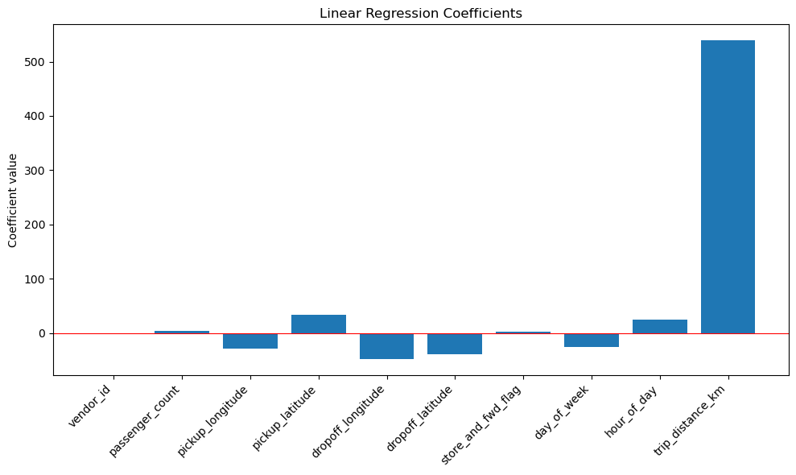

```python
# Bar chart of the linear regression coefficients, to visually compare feature influence
plt.figure(figsize=(10, 6))
plt.bar(coef_df['Feature'], coef_df['Coefficient'])
plt.xticks(rotation=45, ha='right')
plt.ylabel('Coefficient value')
plt.title('Linear Regression Coefficients')
plt.axhline(y=0, color='red', linewidth=0.8)
plt.tight_layout()
plt.show()
```

# Report:

The linear regression coefficients show how much each feature contributes to the predicted trip duration, since the features were scaled before training, the coefficient sizes can be fairly compared against each other. trip_distance_km has by far the largest coefficient at about 539. Because the features are standardized, this means a one-standard-deviation increase in trip distance is associated with roughly a 539 second increase in predicted trip duration, holding the other scaled features constant, it does not mean "1 km adds 539 seconds." This still supports the idea that distance has the strongest linear contribution to the prediction. The coordinate features also have large coefficients, but these are harder to interpret directly since they represent location rather than a simple measurable quantity, and are related to how trip_distance_km itself was calculated. hour_of_day (24.68) and day_of_week (-25.83) also meaningfully affect trip duration. vendor_id has almost no effect (-0.044), suggesting which company operated the trip barely matters for predicting duration once the other features are included.

# Report:

The bar chart makes the pattern from the coefficient table easier to see at a glance. The trip_distance_km bar is far taller than all the others, visually confirming it has the strongest contribution to the prediction. Most other features sit close to zero, with only the coordinates, hour_of_day, and day_of_week showing a moderate effect in either direction, while vendor_id and store_and_fwd_flag are barely visible on the chart.

```python
# Calculate residuals (actual - predicted) for the Linear Regression model on the test set
residuals = pd.DataFrame({
    'fitted values': y_test,
    'predicted values': lr_pred,
})
residuals['residuals'] = residuals['fitted values'] - residuals['predicted values']

residuals.head()
```

|  | fitted values | predicted values | residuals |
| --- | --- | --- | --- |
| 133726 | 667 | 740.128757 | -73.128757 |
| 315218 | 974 | 653.446691 | 320.553309 |
| 1385211 | 1550 | 950.301706 | 599.698294 |
| 1090024 | 1179 | 732.078469 | 446.921531 |
| 936909 | 602 | 665.477961 | -63.477961 |

# Report:

Residuals were calculated as the difference between the actual trip duration and the predicted trip duration for each trip in the test set. A positive residual means the model underestimated the trip duration (actual was higher than predicted), while a negative residual means the model overestimated it. Looking at the first few rows, the residuals vary in both size and direction, which is expected before checking the overall pattern in the next step.

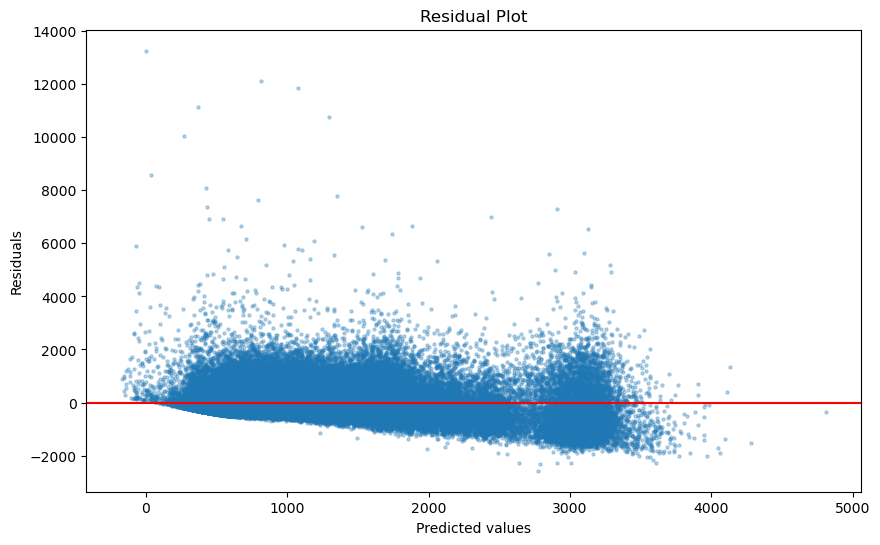

```python
# Plot residuals against fitted (predicted) values, with a red line at 0.
# Residuals should scatter randomly around 0 with no clear pattern.
plt.figure(figsize=(10, 6))
plt.scatter(residuals['predicted values'], residuals['residuals'], alpha=0.3, s=5)
plt.axhline(y=0, color='red')
plt.xlabel('Predicted values')
plt.ylabel('Residuals')
plt.title('Residual Plot')
plt.show()
```

# Report:

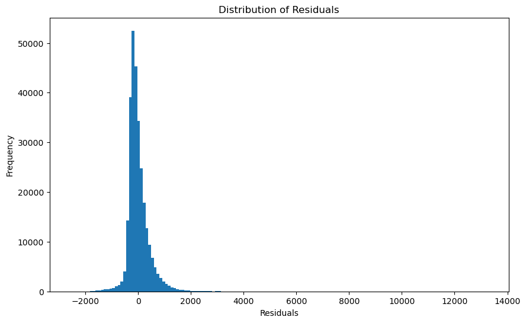

```python
# Histogram of residuals, to check whether errors are roughly normally distributed
plt.figure(figsize=(10, 6))
plt.hist(residuals['residuals'], bins=150)
plt.xlabel('Residuals')
plt.ylabel('Frequency')
plt.title('Distribution of Residuals')
plt.show()
```

# Report:

The histogram of residuals shows a shape that is roughly bell-like and centered close to zero, meaning most predictions are fairly close to the actual trip duration. However, the distribution is not perfectly symmetrical, there is a longer tail stretching to the right, meaning there are a number of trips where the model significantly underestimated the actual trip duration (large positive residuals). This matches what we saw in the residual plot, where the model struggled more with certain predictions than others.

# QQ plot

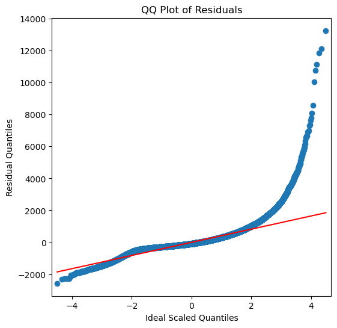

```python
# QQ plot: compares residuals to an ideal normal distribution
from statsmodels.graphics.gofplots import qqplot

fig, ax = plt.subplots(figsize=(6,6), dpi=100)
qqplot(residuals['residuals'], line='s', ax=ax)
plt.ylabel('Residual Quantiles')
plt.xlabel('Ideal Scaled Quantiles')
plt.title('QQ Plot of Residuals')
plt.show()
```

# Report:

The QQ plot compares the residuals to what a perfectly normal distribution would look like. In the middle section, the blue points follow the red line reasonably closely, meaning most residuals are close to normally distributed. However, the points curve sharply upward and away from the red line at the higher end (right side), meaning there are more extreme positive residuals than a normal distribution would predict. This confirms what we saw in the histogram, there is a long tail of trips where the model underestimated the trip duration by a large amount. This suggests the residuals are not perfectly normally distributed, which is a limitation of the linear regression model on this dataset.

# Overall summary of the diagnostics:

The Linear Regression diagnostic plots show that the model does not fully capture the patterns in trip duration. The residual plot shows errors spread around the zero line, with larger errors appearing for some longer trips. The residual histogram and QQ plot also show that the errors are not perfectly normally distributed.

Linear Regression achieved an R^2 of 0.599, while KNN achieved an R^2 of 0.754. KNN also achieved lower MAE and RMSE on the test set. This suggests that KNN captured the relationships in this dataset better than Linear Regression.

Therefore, based on the evaluation results, KNN performed better than Linear Regression for predicting taxi trip duration in this project.

# Final Conclusion

The goal of this project was to predict NYC taxi trip duration using the trip and location data provided. From the EDA, it was clear trip duration is affected by several things - time of day and day of the week both showed patterns (e.g. certain hours had longer average trips), and vendor and passenger count showed some observable differences too, although weaker. However, once the Linear Regression model was built, the coefficients showed passenger_count still had a small positive effect, but vendor_id contributed almost nothing (-0.044) once the other features were included, suggesting the vendor differences seen in EDA don't hold up as a meaningful predictor in the final model.

For preprocessing, I checked for missing values and duplicates and found none. I removed columns that were either irrelevant (id, raw timestamps) or leakage (log_trip_duration, since it's directly derived from the target). For outliers in trip_duration, passenger_count, and the coordinates, I didn't just use the standard IQR method, because it would have removed a large amount of valid data (over 74,000 trips in the case of trip_duration alone). Instead I used domain based cutoffs which removed a much smaller, more justified portion of the data overall. I also engineered a new feature, trip_distance_km, calculated from the pickup and dropoff coordinates, since raw latitude/longitude values don't represent actual distance on their own.

I trained and compared two models: KNN Regression and Linear Regression. For KNN, I tested several values of K and used 5-fold cross-validation to confirm the best one, which came out to K=15.

The final results were:

- KNN (K=15): MAE = 199.90 seconds, RMSE = 322.82 seconds, R2 = 0.754
- Linear Regression: MAE = 277.96 seconds, RMSE = 412.05 seconds, R2 = 0.599

Based on these results, KNN (K=15) is the better model for this dataset.

# Model Export (Stage 6 - Deployment Prep)

```python
# Export the final trained model and scaler for deployment
import joblib

joblib.dump(final_knn, 'knn_model.pkl')
joblib.dump(scaler, 'scaler.pkl')

print("Model and scaler saved successfully.")
print("Files created: knn_model.pkl, scaler.pkl")
```

```
Model and scaler saved successfully.
Files created: knn_model.pkl, scaler.pkl
```